# FIFA18

Kesong Wu

2018/4/29

## Introduction

We will use the statistical information of football plyers inthe video game FIFA 18.

## Load the data and Clean the data

There are three tables we may use in this project.

Let’s have a glimpse on the data.

```
## [1] 17981    15
```

```
## Observations: 17,981
## Variables: 15
## $ X           <int> 0, 1, 2, 3, 4, 5, 6, 7, 8, 9, 10, 11, 12, 13, 14, ...
## $ Unnamed..0  <int> 0, 1, 2, 3, 4, 5, 6, 7, 8, 9, 10, 11, 12, 13, 14, ...
## $ ID          <int> 20801, 158023, 190871, 176580, 167495, 188545, 193...
## $ Name        <fct> Cristiano Ronaldo, L. Messi, Neymar, L. Suárez, M...
## $ Age         <int> 32, 30, 25, 30, 31, 28, 26, 26, 27, 29, 31, 26, 25...
## $ Photo       <fct> https://cdn.sofifa.org/48/18/players/20801.png, ht...
## $ Nationality <fct> Portugal, Argentina, Brazil, Uruguay, Germany, Pol...
## $ Flag        <fct> https://cdn.sofifa.org/flags/38.png, https://cdn.s...
## $ Overall     <int> 94, 93, 92, 92, 92, 91, 90, 90, 90, 90, 90, 89, 89...
## $ Potential   <int> 94, 93, 94, 92, 92, 91, 92, 91, 90, 90, 90, 92, 92...
## $ Club        <fct> Real Madrid CF, FC Barcelona, Paris Saint-Germain,...
## $ Club.Logo   <fct> https://cdn.sofifa.org/24/18/teams/243.png, https:...
## $ Value       <fct> €95.5M, €105M, €123M, €97M, €61M, €92M...
## $ Wage        <fct> €565K, €565K, €280K, €510K, €230K, €35...
## $ Special     <int> 2228, 2154, 2100, 2291, 1493, 2143, 1458, 2096, 21...
```

```
## [1] 17981    29
```

```
## Observations: 17,981
## Variables: 29
## $ X                   <int> 0, 1, 2, 3, 4, 5, 6, 7, 8, 9, 10, 11, 12, ...
## $ CAM                 <dbl> 89, 92, 88, 87, NA, 84, NA, 88, 83, 81, 70...
## $ CB                  <dbl> 53, 45, 46, 58, NA, 57, NA, 47, 72, 46, 87...
## $ CDM                 <dbl> 62, 59, 59, 65, NA, 62, NA, 61, 82, 52, 83...
## $ CF                  <dbl> 91, 92, 88, 88, NA, 87, NA, 87, 81, 84, 70...
## $ CM                  <dbl> 82, 84, 79, 80, NA, 78, NA, 81, 87, 71, 74...
## $ ID                  <int> 20801, 158023, 190871, 176580, 167495, 188...
## $ LAM                 <dbl> 89, 92, 88, 87, NA, 84, NA, 88, 83, 81, 70...
## $ LB                  <dbl> 61, 57, 59, 64, NA, 58, NA, 59, 76, 51, 84...
## $ LCB                 <dbl> 53, 45, 46, 58, NA, 57, NA, 47, 72, 46, 87...
## $ LCM                 <dbl> 82, 84, 79, 80, NA, 78, NA, 81, 87, 71, 74...
## $ LDM                 <dbl> 62, 59, 59, 65, NA, 62, NA, 61, 82, 52, 83...
## $ LF                  <dbl> 91, 92, 88, 88, NA, 87, NA, 87, 81, 84, 70...
```

[output cut: 16 more lines]

```
## [1] 17981    36
```

```
## Observations: 17,981
## Variables: 36
## $ X                  <int> 0, 1, 2, 3, 4, 5, 6, 7, 8, 9, 10, 11, 12, 1...
## $ Acceleration       <fct> 89, 92, 94, 88, 58, 79, 57, 93, 60, 78, 75,...
## $ Aggression         <fct> 63, 48, 56, 78, 29, 80, 38, 54, 60, 50, 84,...
## $ Agility            <fct> 89, 90, 96, 86, 52, 78, 60, 93, 71, 75, 79,...
## $ Balance            <fct> 63, 95, 82, 60, 35, 80, 43, 91, 69, 69, 60,...
## $ Ball.control       <fct> 93, 95, 95, 91, 48, 89, 42, 92, 89, 85, 84,...
## $ Composure          <fct> 95, 96, 92, 83, 70, 87, 64, 87, 85, 86, 80,...
## $ Crossing           <fct> 85, 77, 75, 77, 15, 62, 17, 80, 85, 68, 66,...
## $ Curve              <fct> 81, 89, 81, 86, 14, 77, 21, 82, 85, 74, 73,...
## $ Dribbling          <fct> 91, 97, 96, 86, 30, 85, 18, 93, 79, 84, 61,...
## $ Finishing          <fct> 94, 95, 89, 94, 13, 91, 13, 83, 76, 91, 60,...
## $ Free.kick.accuracy <fct> 76, 90, 84, 84, 11, 84, 19, 79, 84, 62, 67,...
## $ GK.diving          <fct> 7, 6, 9, 27, 91, 15, 90, 11, 10, 5, 11, 15,...
```

[output cut: 23 more lines]

```
## [1] 18293    74
```

[output not shown]

## Ages of football players

Let’s have a look at the density of the ages of these football player.

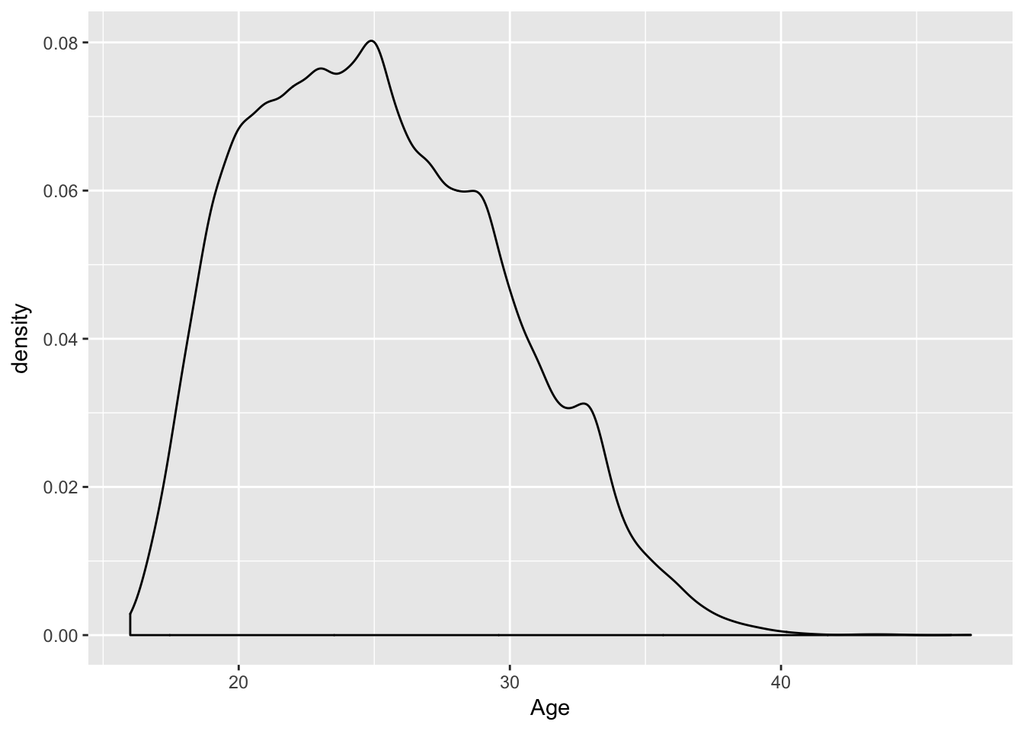

From this plot we can see that most players are between 18 and 30.

## Player’s Overall

Let’s see how the overall scores of all the players are distribute.

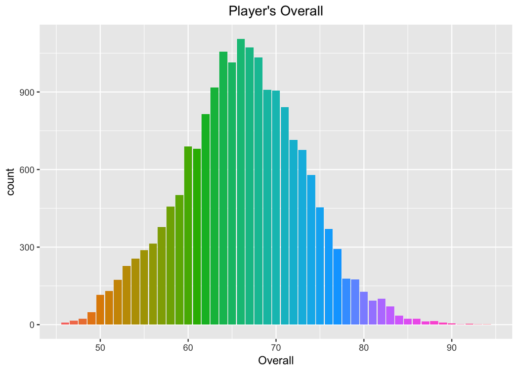

Then let’s see if overall scores are related to players’ ages.

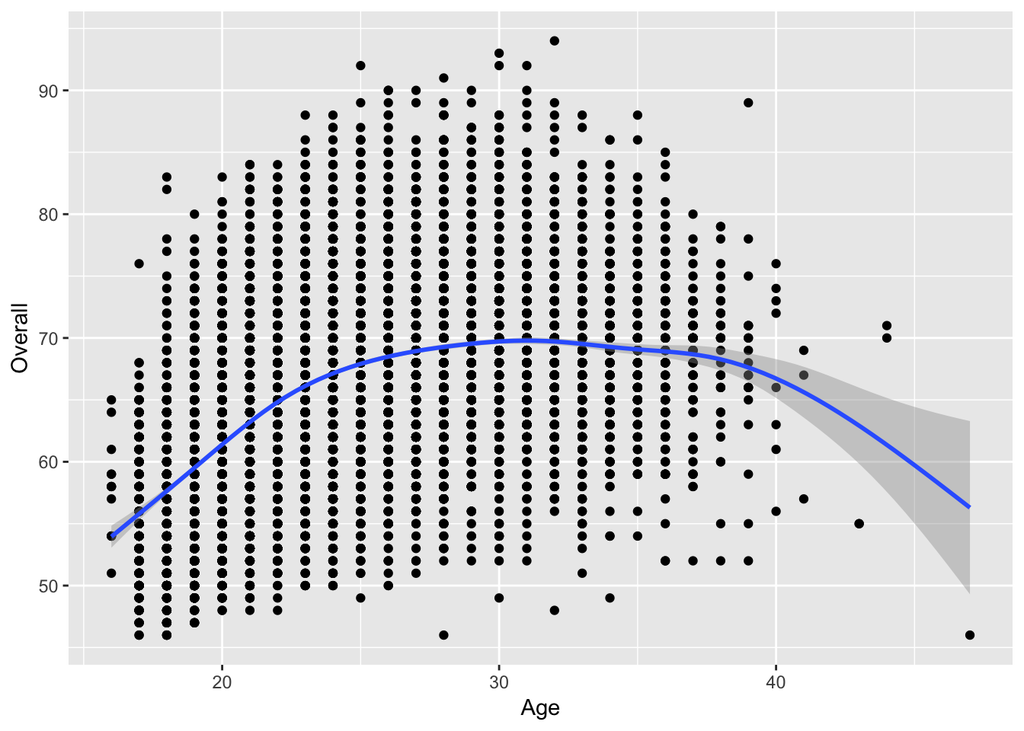

We can see that the players are improving with the step of the years. The best players are 30 years old and after that they start to decline.

## Best Players & Clubs

Based on the overall score, we will find which are the best ten players.

```
##                 Name Overall                Club
## 1  Cristiano Ronaldo      94      Real Madrid CF
## 2           L. Messi      93        FC Barcelona
## 3             Neymar      92 Paris Saint-Germain
## 4   L. Su\303\241rez      92        FC Barcelona
## 5           M. Neuer      92    FC Bayern Munich
## 6     R. Lewandowski      91    FC Bayern Munich
## 7             De Gea      90   Manchester United
## 8          E. Hazard      90             Chelsea
## 9           T. Kroos      90      Real Madrid CF
## 10 G. Higua\303\255n      90            Juventus
```

Then, let’s have a look at each team’s best player’s overall, worst player’s overall and the average overall.

```
## # A tibble: 648 x 4
##    Club                 Best Worst   Ave
##    <fct>               <dbl> <dbl> <dbl>
##  1 FC Barcelona          93.   70.  82.6
##  2 Juventus              90.   69.  81.7
##  3 Real Madrid CF        94.   64.  81.0
##  4 FC Bayern Munich      92.   61.  79.4
##  5 Paris Saint-Germain   92.   61.  78.0
##  6 Manchester United     90.   63.  77.7
##  7 Napoli                87.   53.  77.7
##  8 Roma                  86.   58.  77.4
##  9 Sevilla FC            83.   60.  77.0
## 10 Chelsea               90.   58.  76.7
## # ... with 638 more rows
```

We can see that the best three clubs are FC Barcelona, Juventus and Real Madrid CF.

## Players who earned most and Clubs paid most

```r
fifa$Wage <- gsub("<e2><82><ac>", "", fifa$Wage)
fifa$Wage <- gsub("K", "e+03", fifa$Wage)
fifa$Wage <- as.numeric(fifa$Wage)

fifa %>%
  select(Name, Wage, Club) %>%
  arrange(desc(Wage)) %>%
  head(10)
```

```
##                 Name   Wage             Club
## 1  Cristiano Ronaldo 565000   Real Madrid CF
## 2           L. Messi 565000     FC Barcelona
## 3   L. Su\303\241rez 510000     FC Barcelona
## 4            G. Bale 370000   Real Madrid CF
## 5     R. Lewandowski 355000 FC Bayern Munich
## 6           T. Kroos 340000   Real Madrid CF
## 7   L. Modri\304\207 340000   Real Madrid CF
## 8   S. Ag\303\274ero 325000  Manchester City
## 9       Sergio Ramos 310000   Real Madrid CF
## 10         E. Hazard 295000          Chelsea
```

```r
# I met a problem in this chunk, when I run it in R Markdown, it works, but when I knit this file and output the html file, these numbers will be missing.
```

We can see that, C.Ronaldo and Messi earned most.

```
## # A tibble: 648 x 2
##    Club              TotalWage
##    <fct>                 <dbl>
##  1 FC Barcelona       4792000.
##  2 Real Madrid CF     4751000.
##  3 Manchester United  3558000.
##  4 Chelsea            3537000.
##  5 FC Bayern Munich   3273000.
##  6 Juventus           3165000.
##  7 Manchester City    3057000.
##  8 Arsenal            3007000.
##  9 Liverpool          2664000.
## 10 Everton            2499000.
## # ... with 638 more rows
```

We can see that FC Barcelona, Real Madrid CF and Manchester United paid most.

Let’s combine this result with the best teams result we studied before.

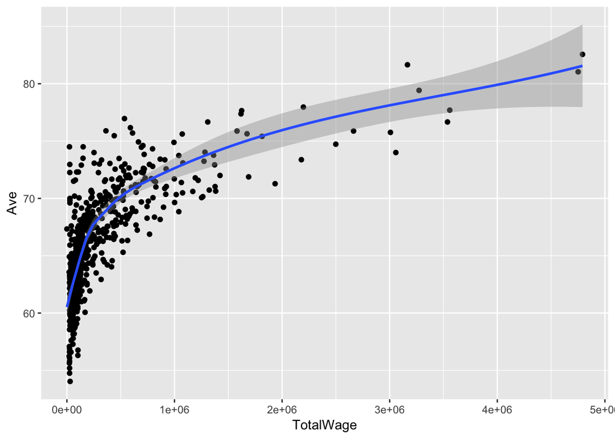

From this plot, we can easily see that, to be a better team, you have to pay more money.

## Players’ Value

We can see that many players might sign a cheap contract before, we now study there value. *We can use sciece notation here.*

```
##                 Name                Club    Value
## 1             Neymar Paris Saint-Germain 1.23e+08
## 2           L. Messi        FC Barcelona 1.05e+08
## 3   L. Su\303\241rez        FC Barcelona 9.70e+07
## 4  Cristiano Ronaldo      Real Madrid CF 9.55e+07
## 5     R. Lewandowski    FC Bayern Munich 9.20e+07
## 6          E. Hazard             Chelsea 9.05e+07
## 7       K. De Bruyne     Manchester City 8.30e+07
## 8           T. Kroos      Real Madrid CF 7.90e+07
## 9          P. Dybala            Juventus 7.90e+07
## 10 G. Higua\303\255n            Juventus 7.70e+07
```

We can see Neymar valued most instead of C.Ronaldo and Messi.

Our table seems better now, and we can output a new csv file for future use.

```r
write.csv(fifa, file = "FIFA18.csv")
```

## Nationalities of the Players

Here we use a new package called “rWorldMap” to show the players’ nationalitites in a world map.

```
## 149 codes from your data successfully matched countries in the map
## 16 codes from your data failed to match with a country code in the map
## 94 codes from the map weren't represented in your data
```

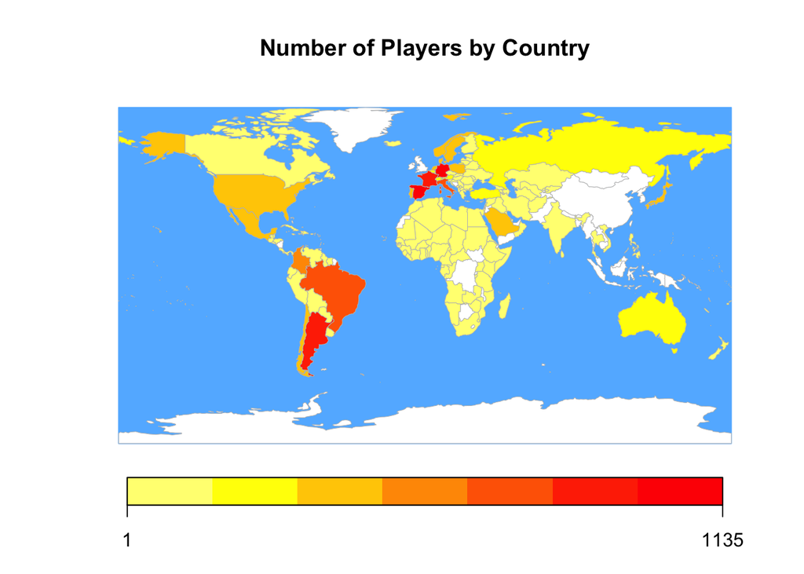

We can see that China has no players in these clubs, European countries and South American countries have the most players.

```
## # A tibble: 10 x 2
##    Nationality     n
##    <fct>       <int>
##  1 England      1629
##  2 Germany      1135
##  3 Spain        1009
##  4 France        973
##  5 Argentina     961
##  6 Brazil        809
##  7 Italy         797
##  8 Colombia      592
##  9 Japan         469
## 10 Netherlands   429
```

These are the countries have most players.

## Players’ Last Name

At this part, I just wanna practice the ^Regular Expression^, but in the data we have, Name is the only part we could use. However, many players’ first names were not given, for example, “Leonardo Messi” is just given as “L.Messi”, so I decided to extract these players’ last name.

```
## # A tibble: 10 x 2
##    name         n
##    <fct>    <int>
##  1 ""        2641
##  2 Silva       43
##  3 Smith       33
##  4 Williams    30
##  5 Torres      28
##  6 Santos      25
##  7 Min         24
##  8 Costa       22
##  9 Taylor      22
## 10 Brown       21
```

For there are many names that are not English letters, we will get many missing values in this progress.

From the result we can see that the most common last name in FIFA18 football players is *“Silva”*.